# Motivazioni e domande

- Gli incidenti stradali possono coinvolgere chiunque in qualsiasi momento durante la guida e ho ritenuto importante effettuare un'analisi su tale tematica.
- Gli incidenti sono in aumento o in calo?
- Su 100 incidenti quante persone rimangono ferite e quante muoiono in media?
- Com'è distribuita la pericolosità delle strade
- Filtrando solo le strade più sicure e più pericolose, come varia l'andamento?

# Descrizione dataset

[Incidenti - Ministero dei trasporti - TSV](https://dati.mit.gov.it/catalog/dataset/f3336ae0-3a6b-4a25-9013-7df0c3750916/resource/130093e5-40f1-498f-82fd-8f36f6740566)

[Feriti - Ministero dei trasporti - TSV](https://dati.mit.gov.it/catalog/dataset/incidenti-morti-feriti-ed-indicatori-dell-incidentalita-stradale-per-mese-anni-2001-2018/resource/9adf3de7-0ca9-479c-8349-466a41d029dc)

[Morti - Ministero dei trasporti - TSV](https://dati.mit.gov.it/catalog/dataset/incidenti-morti-feriti-ed-indicatori-dell-incidentalita-stradale-per-mese-anni-2001-2018/resource/8884b221-eea4-4b02-8a96-02d5f9814617)

- Incidenti, feriti e morti nelle strade suddivise per provincia e per anno dal 2003 al 2017
- Ci sono 1923 tratti di strada, raggruppati per strada sono 1161 strade
- Ad esempio la "SS 016 - Adriatica" ha 20 tratti ognuno di essi in provincie diverse

## Limitazioni

- Gli incidenti possono avvenire in qualunque posto ma questi dataset tengono conto solo delle autostrade e strade extraurbane.

# Analisi dati

- Feriti, incidenti e morti per anno
- Distribuzione incidenti per km
- Strade più pericolose

## Feriti, incidenti e morti per anno

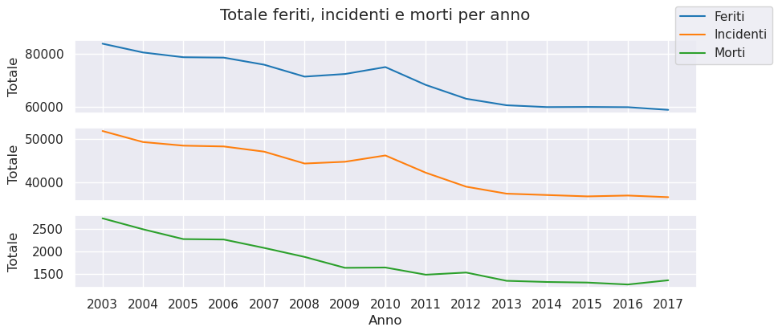

- In media i feriti, incidenti e morti sono risp. 191, 118, e 5 al giorno
- Dal 2003 al 2017 i feriti, incidenti e morti sono diminuiti risp. del 29.6%, 29.5% e 50.3%
- Aumento di feriti, incidenti e morti dal 2009 al 2010 risp. del 3.6%, 3.3% e 0.4%

### Rapporto feriti e morti per incidente

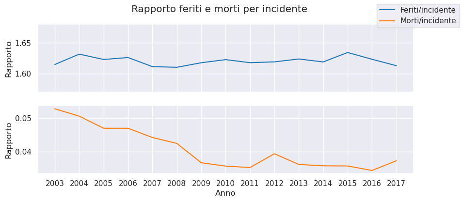

- In media 162 feriti e 4 morti ogni 100 incidenti
- Coefficiente di correlazione Pearson risp. 0.9994 e 0.9344

## Distribuzione incidenti per km

- raggruppando i tratti per codice strada,
- per ogni anno: sommando gli incidenti di ogni tratto e calcolando la media tra le somme calcolate

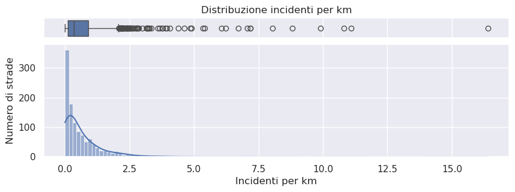

- La mediana è 0.35 incidenti al km ogni anno, moda 0.27, limite superiore boxplot: 2
- 909 strade (78%) hanno meno di 1 incidente/km

### Filtrando solo le strade con più di 2 incidenti al km (83 strade)

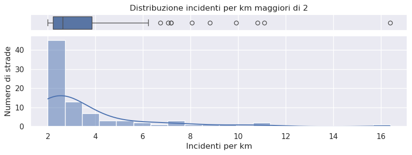

- 19 strade su 1161 (1.63%) hanno più di 4 incidenti al km ogni anno
- 3 strade (0.25%) con più di 10 incidenti al km

## Strade più pericolose

- Le strade più pericolose sono quelle con più incidenti per km
- Classifica 6 strade più pericolose
- Plot totale e rapporto delle 83 strade più pericolose

### Classifica 6 strade più pericolose

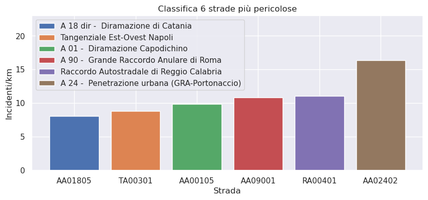

- L'autostrada A24 ha in media 16.4 incidenti/km
- Tutte e 6 le strade sono compose da 1 solo tratto,
- Si trovano rispettivamente a: Catania, Napoli, Napoli, Roma, Reggio Calabria, e Roma

### Feriti, incidenti e morti nelle 83 strade più pericolose

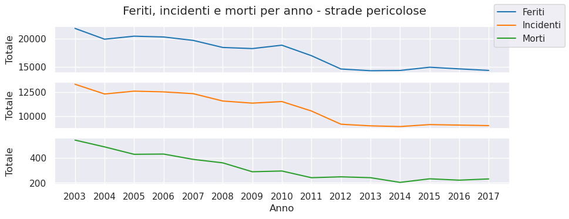

- I feriti, incidenti e morti sono diminuiti del: 33.9%, 32.2%, 57.6%
- Aumento di feriti, incidenti e morti dal 2009 al 2010 risp. del 3.27%, 1.45% e 2.08%

### Rapporto feriti e morti per incidente nelle 83 strade più pericolose

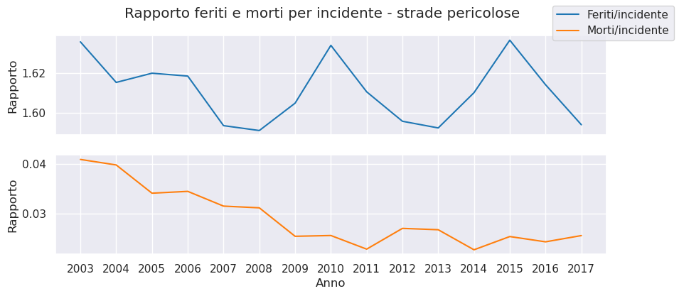

- In media 161 feriti e 3 morti ogni 100 incidenti
- Coefficiente di correlazione di Pearson risp. 0.9981 e 0.9161

# Conclusione

- Gli incidenti sono in calo del 30% circa,
- In media 162 feriti e 4 morti ogni 100 incidenti
- 909 strade su 1161 (78%) hanno meno di 1 incidente al km, e solo 3 strade hanno decine di incidenti al km
- Nelle 83 strade più pericolose: 32% incidenti in meno